# Characterisation of healthy samples from American Gut Project

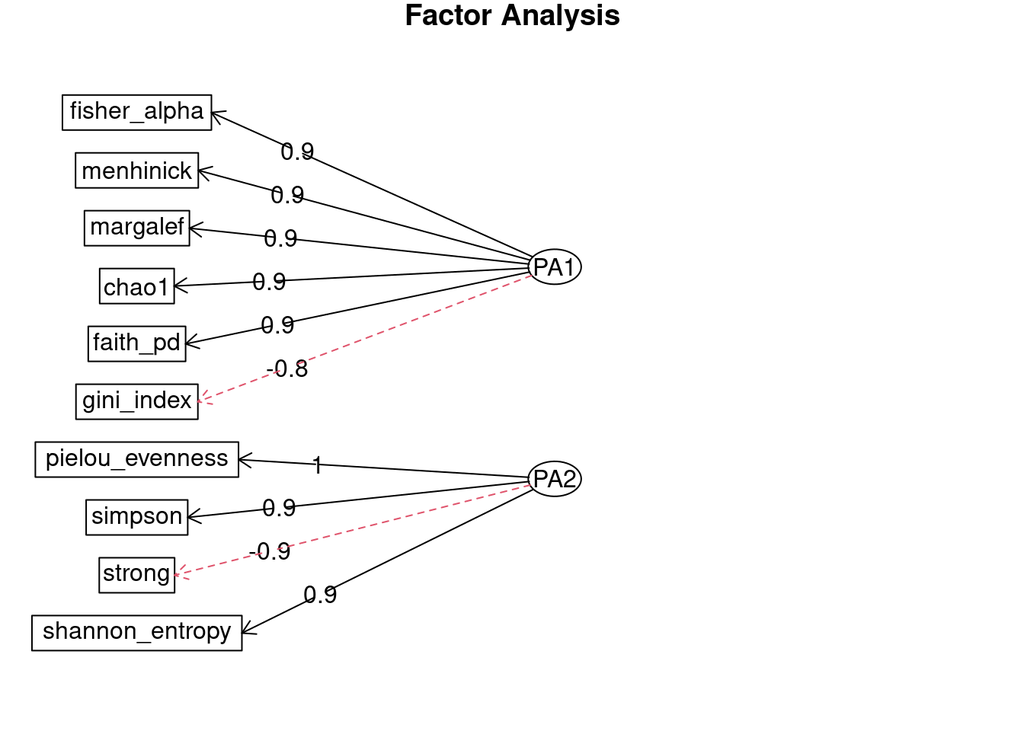

```r
fa.diagram(fa.none)
```

EFA shows that there are two underlying factors that probably indicate richness and evenness. However, due to these metrics being non-normally distributed, the results of this analysis might be compromised.

For other numerical variables we can perform simple Pearson’s correlation coefficient:

```r
# Identify numeric columns
num_cols <- unlist(lapply(all_healthy, is.numeric))

# Subset numeric columns of data
data_num <- all_healthy[ , num_cols]
data_num$birth_year <- NULL

# Save results as data frame
correlation_num <- as.data.frame(cor(data_num[-c(11:14)], data_num[-c(1:10)]))
correlation_num %>% tibble::rownames_to_column() %>% flextable()
```

| rowname | host_age | host_body_mass_index | host_height | host_weight |
| --- | --- | --- | --- | --- |
| shannon_entropy | -0.04886352 | 0.04188236 | -0.02994916 | 0.008910436 |
| chao1 | 0.10231117 | 0.04474715 | -0.04257975 | -0.009474536 |
| menhinick | 0.09040333 | 0.05097968 | -0.03844779 | 0.006267121 |
| margalef | 0.09040333 | 0.05097968 | -0.03844779 | 0.006267121 |
| fisher_alpha | 0.09321034 | 0.05527337 | -0.04039465 | 0.003109535 |
| gini_index | -0.02055728 | -0.07428175 | 0.03751322 | -0.017322337 |
| strong | 0.08248789 | -0.04388722 | 0.01497843 | -0.032589904 |
| simpson | -0.08625915 | 0.02382686 | -0.02972105 | -0.013453246 |
| faith_pd | 0.09033625 | 0.05943272 | -0.05116997 | -0.004187110 |
| pielou_evenness | -0.08875194 | 0.03474628 | -0.02535921 | 0.005252790 |

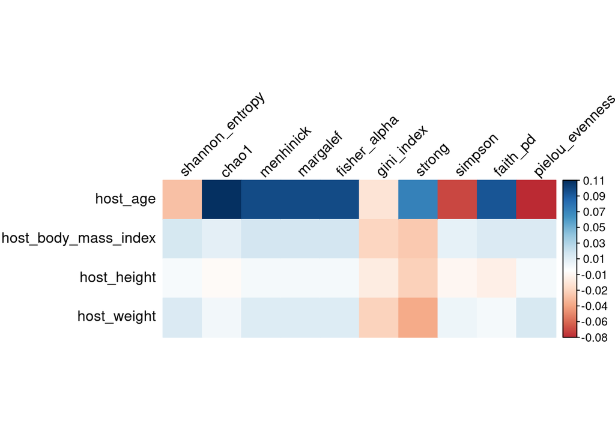

```r
# Plot correlation
cor_matrix <- cor(data_num[-c(1:10)], data_num[-c(11:14)] , method = "spearman")

corrplot(cor_matrix, method = 'color', tl.col = "black", tl.srt = 45, is.corr = FALSE)
```

Correlations between numerical variables and alpha metrics are really weak. We can conclude that age, BMI height and weight do not affect significantly alpha diversity (*we have already filtered out samples of age <20 and >69 and of BMI <18,5 and >25).

### Explore correlations of categorical variables with alpha metrics

For a simple case of linear regression, where continuous dependent variable is Y and there is just one continuous variable X, the numeric value of the r-squared is equal to the square of the correlation of X and Y.

Now if we have one continuous variable and one categorical variable, it is impossible to calculate the correlation between them. However, we can use regression to derive the coefficient of determination that can be treated similarly to correlation. For that, we need to make a regression model taking the continuous variable as dependent variable and categorical variable as independent variable ([source link](https://rpubs.com/riazakhan94/correlation_between_categorical_and_continuous_variable)). This is possible because as long as dependent variable is continuous, the predictors can be anything (nominal or ordinal categorical, or continuous, or a mix) ([source link](https://stats.stackexchange.com/questions/267121/regression-for-categorical-independent-variables-and-a-continuous-dependent-one)). The model gives a r-sq value that represents the *proportion of the variance in the response variable of a regression model that can be explained by the predictor variables*. This value ranges from 0 to 1 ([source link](https://www.statology.org/multiple-r-vs-r-squared/)). We need to take the square root of that r-sq value.

More info about the interpretation: [source link](https://www.statology.org/r-linear-regression-with-categorical-variables/)

```r
# Extract categorical variables from all_healthy data frame:
cat_cols <- unlist(lapply(all_healthy, is.character))

# Subset numeric variables from meta data:
data_cat <- all_healthy[ , cat_cols]
data_cat$sample_id <- NULL
data_cat$condition <- NULL
```

```r
# Calculate regression coefficient for all categorical variables in relation to all alpha diversity metrics
correlation_cat <- data.frame(variable=character(0))

for (i in 1:ncol(data_cat)){
  correlation_cat[i,1] <- colnames(data_cat)[i]
}

for (j in 2:11){
  temp <- data.frame(col = numeric(0))
  for (i in 1:ncol(data_cat)){
    names(temp)[1] <- colnames(all_healthy)[j]
    model <- lm(all_healthy[,j] ~ data_cat[,i])
    sumry <- summary(model)
    r <- sqrt(sumry$r.squared)
    temp[i,1] <- r
  }
  correlation_cat <- cbind(correlation_cat, temp)
}

modelXY <- lm(all_healthy$shannon_entropy ~ data_cat$age_cat)


## model summary
sumryXY <- summary(modelXY)

## r-sq of model
rsqXY <- sumryXY$r.squared
```

```r
# Extract first 10 variables with the biggest influence on alpha metrics
most_correlated <- data.frame(variable=character(20),regression_coefficient=numeric(20))

for (j in 2:11){
  temp <- data.frame(variable=character(20), regression_coefficient=numeric(20))
  names(temp)[2] <- paste("regression_coefficient", colnames(correlation_cat)[j], sep="_")
  temp[,1] <- head(correlation_cat[order(-correlation_cat[,j]),]$variable, 20)
  temp[,2] <- head(correlation_cat[order(-correlation_cat[,j]),][,j], 20)
  most_correlated <- cbind(most_correlated, temp)
}

most_correlated[,1:2] <- NULL
```

Plot “correlations” of categorical variables:

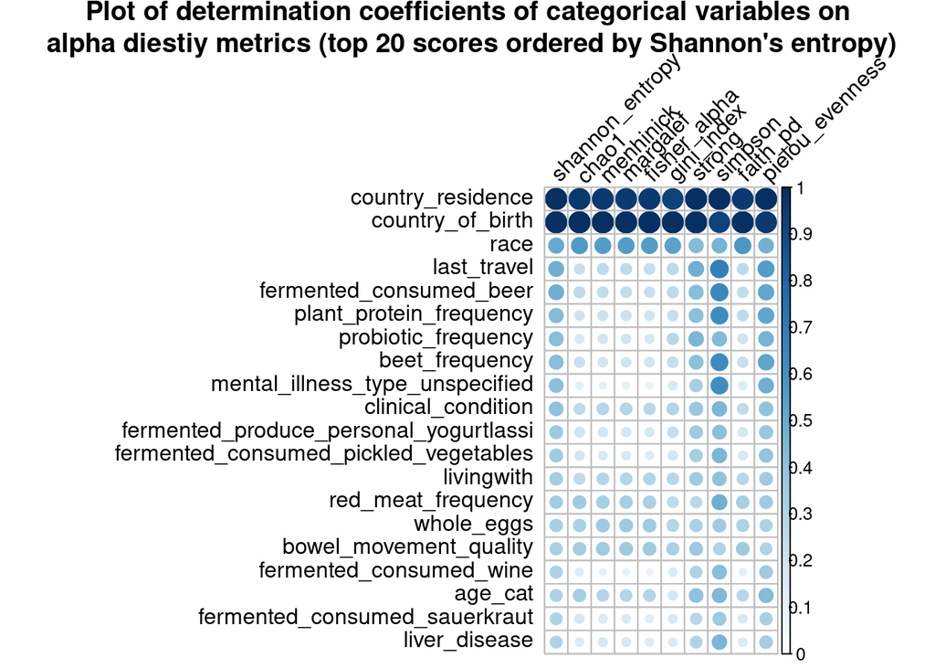

```r
# Transform correlation_cat data frame to matrix
cor_matrix_cat <- correlation_cat %>% column_to_rownames(var = "variable")
cor_matrix_cat <- data.matrix(cor_matrix_cat)

# Scale regression coefficients from 0 to 1 and order matrix by the decreasing value of Shannon's entropy
dat <- as.matrix(apply(cor_matrix_cat, MARGIN = 2, FUN = function(X) (X - min(X))/diff(range(X))))
dat <- dat[order(dat[,1], decreasing=TRUE),]

# Plot the "correlation" matrix
corrplot(dat[1:20,], tl.col = "black", tl.srt = 45, col.lim = c(0,1),  title = "Plot of determination coefficients of categorical variables on\n alpha diestiy metrics (top 20 scores ordered by Shannon's entropy)", mar=c(0,0,2,0))
```

Based on determination coefficients we would expect that country of birth and country of residence impact the alpha diversity (geographical differences could impact lifestyle and diet, also different heritage)

## Random forest - feature importance

Lets try to quantify importance of different categorical variables for each alpha diversity metric:

```r
library(readxl)
#install.packages("randomForest")
library(randomForest)
#install.packages("varImp")
library(varImp)
```

```
## mtry = 59  OOB error = 1.495048
## Searching left ...
## mtry = 40    OOB error = 1.493186
## 0.001245749 0.01
## Searching right ...
## mtry = 88    OOB error = 1.496521
## -0.0009853393 0.01
```

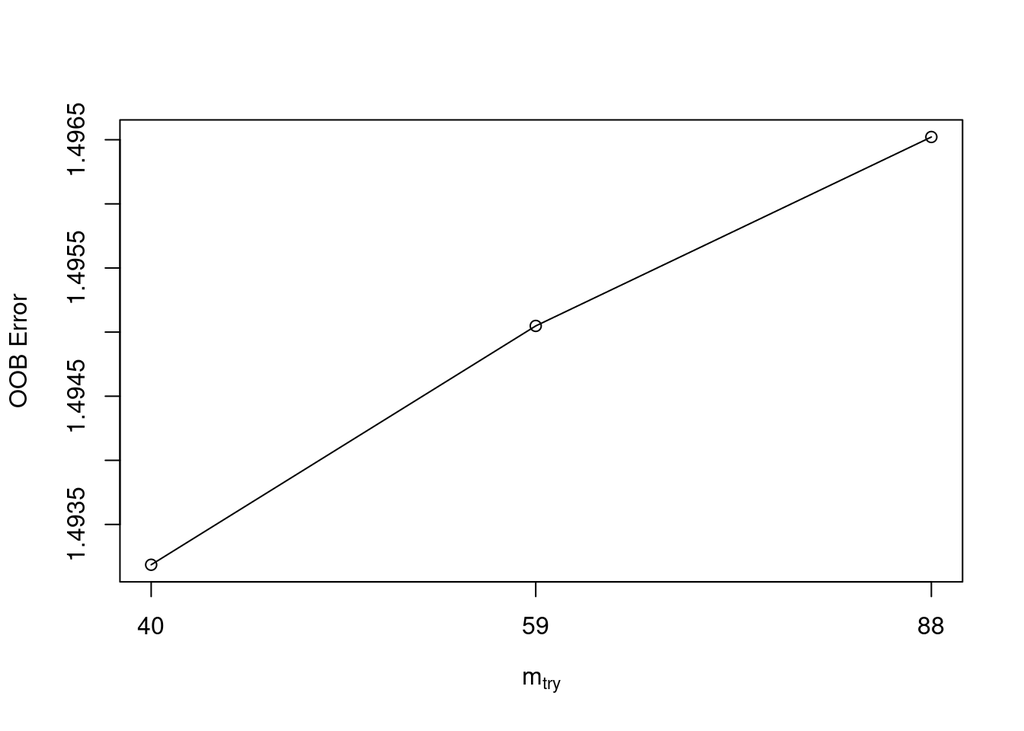

```r
data_cat_rf <- all_healthy[ , cat_cols]
data_cat_rf$sample_id <- NULL
data_cat_rf$shannon_entropy <- all_healthy$shannon_entropy

# Random Forest Modelling
#model <- randomForest(shannon_entropy ~ ., data = data_cat_rf, ntree=500)

# The number of variables selected at each split is denoted by mtry in randomforest function.
# Let's find the optimal mtry value:
mtry <- tuneRF(data_cat_rf[,1:178],data_cat_rf$shannon_entropy, ntreeTry=500,
               stepFactor=1.5,improve=0.01, trace=TRUE, plot=TRUE)
```

```r
best.m <- mtry[mtry[, 2] == min(mtry[, 2]), 1]
print(mtry)
```

```
##    mtry OOBError
## 40   40 1.493186
## 59   59 1.495048
## 88   88 1.496521
```

```r
print(best.m)
```

```
## [1] 40
```

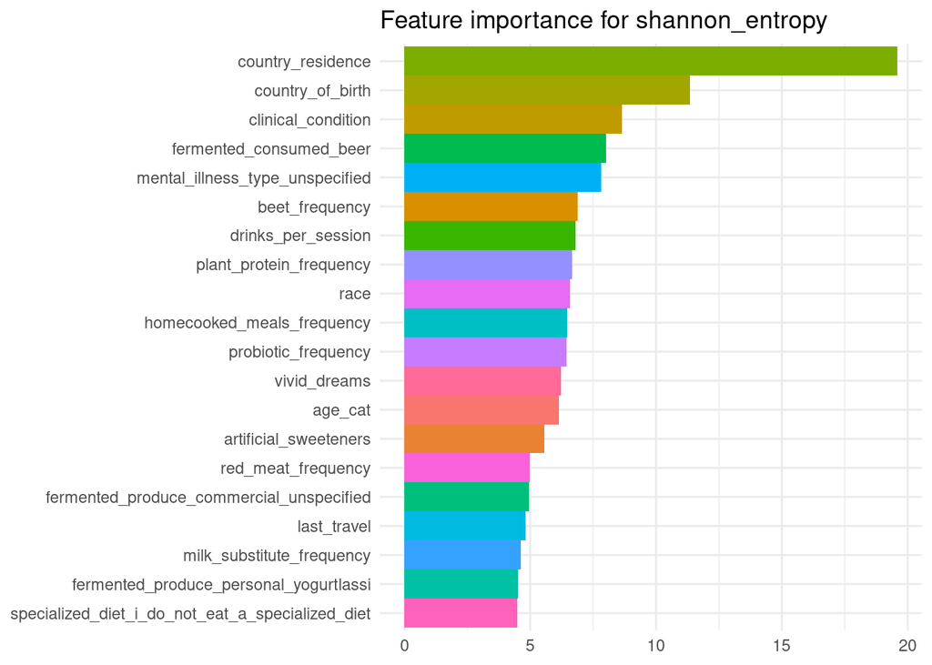

```r
# Now use optimal mtry (the one with minimum bag(OOB) error.) in new model:
rf <-randomForest(shannon_entropy~., data=data_cat_rf, mtry=best.m, importance=TRUE,ntree=500)

#plot(rf)
#varImpPlot(rf)

#Conditional=True, adjusts for correlations between predictors.
i_scores <- caret::varImp(rf, conditional = TRUE)

#Gathering rownames in 'var'  and converting it to the factor
#to provide 'fill' parameter for the bar chart.
i_scores <- i_scores %>% tibble::rownames_to_column("var")
i_scores$var<- i_scores$var %>% as.factor()
i_scores <- arrange(i_scores, desc(Overall))
i_scores_plot <- i_scores[1:20,]

#Plotting the bar and polar charts for comparing variables
i_bar <- i_scores_plot %>% ggplot(aes(x = Overall, y= reorder(var, Overall), fill = var)) +
  geom_bar(stat = "identity", show.legend = FALSE, width = 1) +
  labs(x = NULL, y = NULL, title = "Feature importance for shannon_entropy")+
  theme_minimal()
plot(i_bar)
```

```r
######################################################################
###Try to make a loop to go over all alpha metrics -> still not working

# for (i in 1:length(metric)){
#   data_cat_rf <- all_healthy[ , cat_cols]
#   data_cat_rf$sample_id <- NULL
#   data_cat_rf[[metric[i]]] <- all_healthy[[metric[i]]]
#
#
#   # The number of variables selected at each split is denoted by mtry in randomforest function.
#   # Let's find the optimal mtry value:
#   mtry <- tuneRF(data_cat_rf[-1], data_cat_rf[[metric[i]]], ntreeTry=500,
#                  stepFactor=1.5, improve=0.01, trace=TRUE, plot=TRUE)
#   best.m <- mtry[mtry[, 2] == min(mtry[, 2]), 1]
#
#   # Now use optimal mtry (the one with minimum "out of the bag” (OOB) error.) in new model:
#   rf <-  randomForest(data_cat_rf[[metric[i]]] ~ ., data = data_cat_rf, mtry=best.m, importance=TRUE, ntree=500)
#
#   #Conditional=True, adjusts for correlations between predictors.
#   i_scores <- caret::varImp(rf, conditional = TRUE)
#
#   #Gathering rownames in 'var'  and converting it to the factor
#   #to provide 'fill' parameter for the bar chart.
#   i_scores <- i_scores %>% tibble::rownames_to_column("var")
#   i_scores$var<- i_scores$var %>% as.factor()
#   i_scores <- arrange(i_scores, desc(Overall)) %>% filter(var!=metric[i])
#   i_scores_plot <- i_scores[1:20,]
#
#   #Plotting the bar and polar charts for comparing variables
#   i_bar <- i_scores_plot %>% ggplot(aes(x = Overall, y= reorder(var, Overall), fill = var)) +
#     geom_bar(stat = "identity", show.legend = FALSE, width = 1) +
#     labs(x = NULL, y = NULL, title = paste("Feature importance for", metric[i], sep=" "))+
#     theme_minimal()
#   plot(i_bar)
# }
```

## How to compare different meta-data categories in the light of alpha diversity?

In order to take deeper insight into differences in alpha diversity of subsets of population stratified by different categorical variables, please check the interactive Shiny app that makes isualisation of population distributions and applies Mann-Whitney-Wilcoxon test to check whether the stratified groups belong to the same distribution.

### Plots for country of birth and residence

Since country of birth and country of residence seem to be highly influential on alpha diversity, lets inspect them more closely.

Stratifying samples into different countries is not that meaningful. Lets group these countries into continents:

```r
library(stringr)
cols <- c("sample_id", "shannon_entropy", "chao1", "menhinick", "margalef", "fisher_alpha", "gini_index", "pielou_evenness" , "simpson", "strong", "faith_pd","country_of_birth", "country_residence" )
healthy_countries <- all_healthy[, names(all_healthy) %in% cols]

europe <- c("Albania", "Austria", "Belarus", "Belgium", "Bulgaria", "Croatia", "Czech Republic", "Denmark", "France", "Germany", "Greece", "Gibraltar", "Guernsey", "Hungary", "Ireland", "Italy", "Jersey", "Latvia", "Lithuania", "Moldova, Republic of", "Netherlands", "Norway", "Poland", "Portugal", "Romania", "Russian Federation", "Serbia", "Slovakia", "Spain", "Sweden", "Switzerland", "United Kingdom")
soutrh_america <- c("Argentina", "Chile", "Brazil", "Bolivia", "Colombia", "Peru", "Trinidad and Tobago", "Venezuela")
north_america <- c("Canada", "Mexico", "Panama", "United States", "Jamaica")
asia <- c("Azerbaijan", "China", "Hong Kong", "India", "Iraq", "Iran, Islamic Republic of", "Japan", "Kazakhstan", "Korea, Republic of", "Lebanon", "Malaysia", "Pakistan", "Philippines", "Singapore", "Taiwan, Province of China", "Thailand", "Tunisia", "Turkey", "United Arab Emirates", "Uzbekistan", "Viet Nam", "Bangladesh")
africa <- c("Ethiopia", "Kenya", "Libyan Arab Jamahiriya", "Morocco", "Nigeria", "South Africa", "Tanzania, United Republic of", "Zambia", "Zimbabwe")
australia_oceania <- c("Australia", "New Zealand", "Fiji")

healthy_countries$country_of_birth <- sapply(healthy_countries$country_of_birth, function(x) replace(x, x %in% europe, "Europe"))
healthy_countries$country_of_birth <- sapply(healthy_countries$country_of_birth, function(x) replace(x, x %in% soutrh_america, "South America"))
healthy_countries$country_of_birth <- sapply(healthy_countries$country_of_birth, function(x) replace(x, x %in% north_america, "North America"))
healthy_countries$country_of_birth <- sapply(healthy_countries$country_of_birth, function(x) replace(x, x %in% asia, "Asia"))
healthy_countries$country_of_birth <- sapply(healthy_countries$country_of_birth, function(x) replace(x, x %in% africa, "Africa"))
healthy_countries$country_of_birth <- sapply(healthy_countries$country_of_birth, function(x) replace(x, x %in% australia_oceania, "Australia and Oceania"))

healthy_countries$country_residence <- sapply(healthy_countries$country_residence, function(x) replace(x, x %in% europe, "Europe"))
healthy_countries$country_residence <- sapply(healthy_countries$country_residence, function(x) replace(x, x %in% soutrh_america, "South America"))
healthy_countries$country_residence <- sapply(healthy_countries$country_residence, function(x) replace(x, x %in% north_america, "North America"))
healthy_countries$country_residence <- sapply(healthy_countries$country_residence, function(x) replace(x, x %in% asia, "Asia"))
healthy_countries$country_residence <- sapply(healthy_countries$country_residence, function(x) replace(x, x %in% africa, "Africa"))
healthy_countries$country_residence <- sapply(healthy_countries$country_residence, function(x) replace(x, x %in% australia_oceania, "Australia and Oceania"))

table(healthy_countries$country_of_birth)
```

```
##
##                Africa                  Asia Australia and Oceania
##                    12                    60                    23
##                Europe         North America         South America
##                   607                   753                    15
```

```r
table(healthy_countries$country_residence)
```

```
##
##                Africa                  Asia Australia and Oceania
##                     2                    11                     3
##                Europe         North America         South America
##                   579                   704                     1
##           Unspecified
##                   170
```

Lets filter those continental groups out:

```r
#delete underrepresented values

healthy_countries_2 <- healthy_countries[!(healthy_countries$country_of_birth=="Africa" | healthy_countries$country_of_birth=="Australia and Oceania" | healthy_countries$country_of_birth=="South America" | healthy_countries$country_residence=="Africa" | healthy_countries$country_residence=="Australia and Oceania" | healthy_countries$country_residence=="Asia" | healthy_countries$country_residence=="South America" | healthy_countries$country_residence=="Unspecified"),]

table(healthy_countries_2$country_of_birth)
```

```
##
##          Asia        Europe North America
##            48           570           630
```

```r
table(healthy_countries_2$country_residence)
```

```
##
##        Europe North America
##           560           688
```

Now we are left with samples which country of birth is located in Asia, Europe or North America, and which country of residence is in Europe or North America. Lets see if there is a difference between these groups:

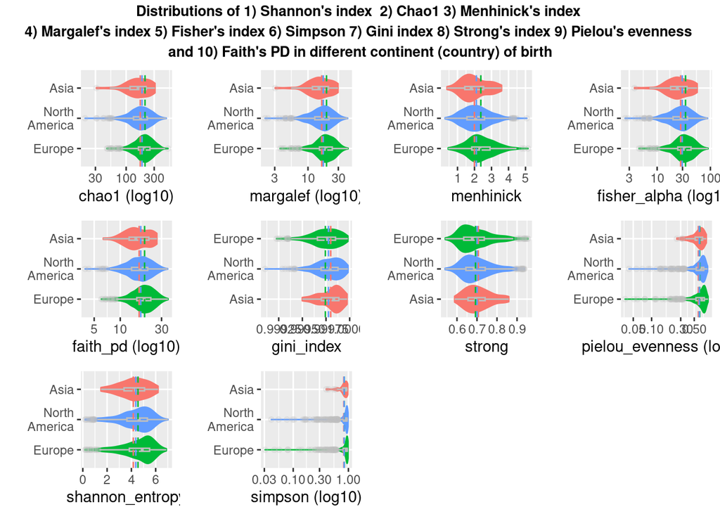

```r
compare <- c("country_of_birth", "country_residence")
violin <- vector('list', length(metric)* length(compare))

for (j in 1:length(compare)){
  for (i in 1:length(metric)){
    mean_line <- healthy_countries_2 %>% dplyr::group_by(.data[[compare[j]]]) %>% dplyr::summarise(grp_mean=mean(.data[[metric[i]]]))
    plot_data <- healthy_countries_2 %>% dplyr::group_by(.data[[compare[j]]]) %>% dplyr::mutate(m = mean(.data[[metric[i]]]))

    violin[[j]][[i]] <- plot_data %>% ggplot(aes(x = .data[[metric[i]]], y = reorder(.data[[compare[j]]], -m), color = .data[[compare[j]]], fill = .data[[compare[j]]])) +
      geom_violin()+
      geom_boxplot(width=0.1, color="grey", alpha=0.2) +
      geom_vline(data = mean_line, aes(xintercept = grp_mean, color = .data[[compare[j]]]), linetype = "dashed")+
      labs(x = metric[i])+
      ylab("")+
      #ggtitle("A Violin plot of distributions of alpha metrics in different conditions")+
      scale_y_discrete(labels = function(x) str_wrap(x, width = 7))+
      theme(legend.position="none")

    if(metric[i] != "shannon_entropy" & metric[i] !="strong" & metric[i] != "gini_index"  &  metric[i] != "menhinick"){
     violin [[j]][[i]] <- violin [[j]][[i]] +
       scale_x_continuous(trans = 'log10') +
       xlab(paste(metric[i], "(log10)", sep = " "))
    }
  }
}

# Show plots for country of birth
grid.arrange(violin[[1]][[1]], violin[[1]][[2]],violin[[1]][[3]], violin[[1]][[4]],violin[[1]][[5]], violin[[1]][[6]],violin[[1]][[7]], violin[[1]][[8]],violin[[1]][[9]], violin[[1]][[10]], ncol=4, top = textGrob("Distributions of 1) Shannon's index  2) Chao1 3) Menhinick's index \n4) Margalef's index 5) Fisher's index 6) Simpson 7) Gini index 8) Strong's index 9) Pielou's evenness \nand 10) Faith's PD in different continent (country) of birth", gp=gpar(fontsize=10,font=2)))
```

For all alpha diversity metrics (except from Gini and Strong’s index) Europe has the highest mean value while Asia has the lowest (also the lowest sample size).

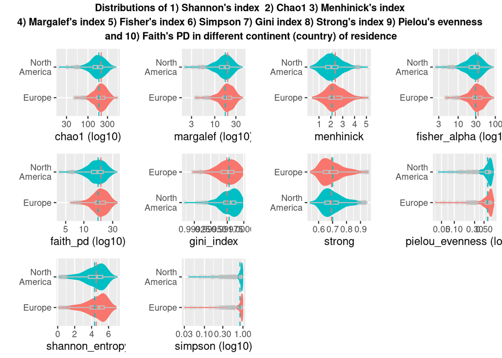

```r
# Show plots for country of birth
grid.arrange(violin[[2]][[1]], violin[[2]][[2]],violin[[2]][[3]], violin[[2]][[4]],violin[[2]][[5]], violin[[2]][[6]],violin[[2]][[7]], violin[[2]][[8]],violin[[2]][[9]], violin[[2]][[10]], ncol=4, top = textGrob("Distributions of 1) Shannon's index  2) Chao1 3) Menhinick's index \n4) Margalef's index 5) Fisher's index 6) Simpson 7) Gini index 8) Strong's index 9) Pielou's evenness \nand 10) Faith's PD in different continent (country) of residence", gp=gpar(fontsize=10,font=2)))
```

For all alpha diversity metrics (except from Gini and Strong’s index) Europe has higher mean value than North America.

```r
test <- list()
tables <- list()

for (j in 1:length(compare)){
  for (i in 1:length(metric)){
    test[[i]] <- pairwise.wilcox.test(healthy_countries_2[[metric[i]]], healthy_countries_2[[compare[j]]], p.adjust.method="none") %>%
    broom::tidy() %>% add_column(parameter = metric[i], .before='group1')
  }

  tables[[j]] <- do.call(what = rbind, args = test)

  tables[[j]] <- tables[[j]] %>%
    add_column(p.adjusted = p.adjust(tables[[j]]$p.value, "fdr"), .after='p.value') %>%
    arrange(p.value, group1)  %>%
    flextable() %>%
    bold(~ p.value < 0.05, 4) %>%
    bold(~ p.adjusted < 0.05, 5) %>%
    add_header_lines(values = "Results of the Wilcox test for distributions of different groups")
}

tables
```

```
## [[1]]
## a flextable object.
## col_keys: `parameter`, `group1`, `group2`, `p.value`, `p.adjusted`
## header has 2 row(s)
## body has 30 row(s)
## original dataset sample:
##      parameter        group1 group2      p.value   p.adjusted
## 1     faith_pd North America Europe 1.959942e-09 5.807553e-08
## 2        chao1 North America Europe 3.871702e-09 5.807553e-08
## 3     margalef North America Europe 1.099885e-08 6.599310e-08
## 4    menhinick North America Europe 1.099885e-08 6.599310e-08
## 5 fisher_alpha North America Europe 1.099885e-08 6.599310e-08
##
## [[2]]
## a flextable object.
## col_keys: `parameter`, `group1`, `group2`, `p.value`, `p.adjusted`
## header has 2 row(s)
## body has 10 row(s)
## original dataset sample:
##      parameter        group1 group2      p.value   p.adjusted
## 1        chao1 North America Europe 4.032815e-11 3.900029e-10
## 2     faith_pd North America Europe 7.800059e-11 3.900029e-10
## 3     margalef North America Europe 5.960406e-10 1.192081e-09
## 4    menhinick North America Europe 5.960406e-10 1.192081e-09
## 5 fisher_alpha North America Europe 5.960406e-10 1.192081e-09
```

Mann-Whitney-Wilcoxon test shows that, when it comes to different countries of birth, there is significant difference (sign. lvl. 0,05) between samples from: *Europe and Asia - for all alpha metrics (Simpson’s index is on the border of signifficance)* Europe and North America - for Faith’s, Menhinick’s, Margalef’s, Fisher’s and Chao1 alpha diversity index.

Furthermore, for different countries of residence, there is significant difference (sign. lvl. 0,05) between samples from: *Europe and North America - for Faith’s, Menhinick’s, Margalef’s, Fisher’s, Chao1 and Gini’s alpha diversity index.

This can indicate that American healthy population is probably not gooing to be equated with european (Spanish) population.